# Prediction Assignment Writeup

Sherif Hassan

January 12, 2018

# Data

The training data for this project are available here: https://d396qusza40orc.cloudfront.net/predmachlearn/pml-training.csv

The test data are available here: https://d396qusza40orc.cloudfront.net/predmachlearn/pml-testing.csv

# What you should submit

The goal of your project is to predict the manner in which they did the exercise. This is the “classe” variable in the training set. You may use any of the other variables to predict with. You should create a report describing how you built your model, how you used cross validation, what you think the expected out of sample error is, and why you made the choices you did. You will also use your prediction model to predict 20 different test cases.

# Reproducibility

Due to security concerns with the exchange of R code, your code will not be run during the evaluation by your classmates. Please be sure that if they download the repo, they will be able to view the compiled HTML version of your analysis.

# Background

Using devices such as Jawbone Up, Nike FuelBand, and Fitbit it is now possible to collect a large amount of data about personal activity relatively inexpensively. These type of devices are part of the quantified self movement - a group of enthusiasts who take measurements about themselves regularly to improve their health, to find patterns in their behavior, or because they are tech geeks. One thing that people regularly do is quantify how much of a particular activity they do, but they rarely quantify how well they do it. In this project, your goal will be to use data from accelerometers on the belt, forearm, arm, and dumbell of 6 participants.

# loading required Libraries

```r
library(dplyr)
```

```r
library(ggplot2)
library(caret)
library(RColorBrewer)
library(randomForest)
library(rpart)
library(reshape2)
library(plyr)
library(lattice)
library(rpart.plot)
```

# Loading (Training and Testing)Data Sets

```r
trainingdataSet <- read.csv("pml-training.csv", na.strings=c("NA","#DIV/0!", ""))

testingdataSet <- read.csv('pml-testing.csv', na.strings=c("NA","#DIV/0!", ""))
#din data
head(trainingdataSet)
```

[output not shown]

[output cut: 265 more lines]

```r
head(testingdataSet)
```

[output not shown]

[output cut: 265 more lines]

```r
dim(trainingdataSet)
```

```
## [1] 19622   160
```

```r
dim(testingdataSet)
```

```
## [1]  20 160
```

# Cleaning Data

```r
Tr_data <- trainingdataSet[, 1:159]; Te_data <- testingdataSet[, 1:159]
final <- rbind(Tr_data ,Te_data)

# Delete Null Values
list_na <- sapply(final, function(x) sum(is.na(x)))
final <- final[, list_na == 0]

# Change Time Stamp
final$hour_of_day <- strftime(as.POSIXct(final$raw_timestamp_part_1, origin = "1970-01-01", tz = "GMT"),format = "%H")
final$hour_of_day <- as.numeric(final$hour_of_day)

final <- final[, -c(1, 3:5, 7)]
```

# Devide training set into two data set to perform cross-validation

```r
s1 <- createDataPartition(y=trainingdataSet$classe, p=0.76, list=FALSE)
Training <- trainingdataSet[s1, ]
Testing <- trainingdataSet[-s1, ]
dim(Training)
```

```
## [1] 14915   160
```

```r
dim(Testing)
```

```
## [1] 4707  160
```

```r
head(Training)
```

[output not shown]

[output cut: 265 more lines]

```r
head(Testing)
```

[output not shown]

[output cut: 272 more lines]

# 1st Predection Type (Random Forest)

```r
set.seed(123)

train <- cbind(final [1:dim(trainingdataSet)[1], ], trainingdataSet[, 160])
names(train)[dim(train)[2]] <- 'classe'
inTrain <- createDataPartition(y = train$classe, p = 0.7, list = F)
training <- train[inTrain, ]; testing <- train[-inTrain,]

RF_model = randomForest(classe ~ ., data = training, ntree=500)
DT_model = rpart(classe ~ ., data = training)


pred <- predict(RF_model, testing)
DE<- data.frame(y = testing$classe, pred = pred)
DE$equal <- 0
for (i in 1:dim(DE)[1]){
        if (DE$y[i] == DE$pred[i]){
                DE$equal[i] <- 1
        } else { DE$equal[i] <- 0 }}
sum(DE$equal)/length(DE$equal)
```

```
## [1] 0.9940527
```

```r
#accuracy with  100%
es <- final[(1+dim(train)[1]):dim(final)[1], ]
predict(RF_model, es)
```

```
## 19623 19624 19625 19626 19627 19628 19629 19630 19631 19632 19633 19634
##     B     A     B     A     A     E     D     B     A     A     B     C
## 19635 19636 19637 19638 19639 19640 19641 19642
##     B     A     E     E     A     B     B     B
## Levels: A B C D E
```

# 2nd Predection type (Decision Tree)

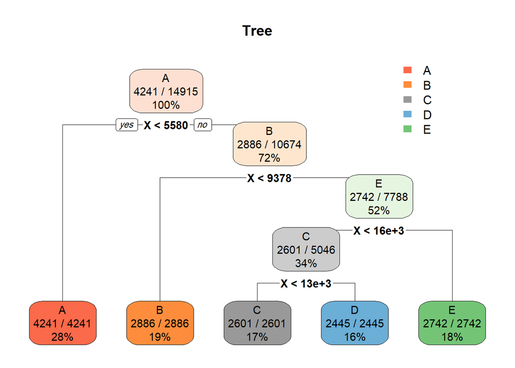

```r
model <- rpart(classe ~ ., data=Training)
prediction_2 <- predict(model , Testing)
# Ploting the Decision Tree
rpart.plot(model, main="Tree", extra=102,  faclen=10)
```

# Best prediction is random forest type

Thanks